# Github Link:

https://github.com/Newtella3105/Teamfight-Tactics-JSC370

# Introduction

This project analyzes champion and trait data from **Teamfight Tactics (TFT)** Sets 12 and 13 to understand how changes in champion cost and design influence balance and performance. TFT, developed by Riot Games, is an auto-battler game where players strategically build teams of champions that automatically fight in a series of combat rounds. Each new “set” introduces fresh units, traits, and mechanics that reshape the meta-game.

Set 13 introduced a major change: **6-cost champions** with **exclusive 4-star upgrades**, expanding the power curve beyond the previous 5-cost maximum. This project aims to investigate how this design shift affects champion statistics, value efficiency, and trait-level impact on performance outcomes.

# Background

In TFT, eight players face off in a round-robin format. Each player assembles a team of **champions** (also known as **units**) drawn from a shared shop. These units battle autonomously on a hexagonal **board** against other players’ teams.

## Key Concepts and Definitions

- **Unit**: A controllable champion with traits, abilities, and stats.
- **Trait**: A label representing a champion’s role or origin (e.g., “Mage”, “Bruiser”). Traits activate bonuses when multiple units share the same trait, creating **synergies**.
- **Cost**: The gold price to buy a unit (1–6). Higher-cost units are rarer and typically stronger.
- **Star Level**: Units can be upgraded:
  - 3 × 1-star → 2-star
  - 3 × 2-star → 3-star
  - 3 × 3-star → 4-star (Set 13 only)  
    The higher the star level, the stronger each attribute and ability of the unit becomes.
- **Health**: Total damage a unit can absorb.
- **Damage**: Damage dealt per basic attack.
- **DPS (Damage Per Second)**: Average damage output per second.
- **Player Level**: Determines how many units a player can deploy (max: 10) and affects odds of finding high-cost units in the shop.
- **Combat Round**: A fight phase where units act automatically.

[figure not shown]

# Scope and Unit of Analysis

The dataset includes win and top4 rates for thousands of team **compositions** (not individual units). (Note: win rate refers to the Top 1 Rate, i.e., the proportion of games where a composition finishes first. Each composition is a unique arrangement of champions and traits. Thus:

- **Each observation is a team composition**.
- **Performance metrics (win/top4 rate) are per composition**.
- To analyze **unit-level impact**, we decompose each composition into its champions and traits, then compute **average performance** for each unit or trait based on all compositions it appears in.  
  These are not raw per-unit win rates but are **derived values** from aggregate composition performance.

# Research Questions

- How do champion stats (health, damage, DPS) scale with cost in Set 13 compared to Set 12, and how does this affect win rate?
- How does the distribution of win rates vary across champion cost tiers and traits?
- Are normalized stats (stat divided by total cost at star level) predictive of win rate?
- Which predictors (stats, traits, or both) best explain champion-level win rate?
- Which model type (LM, GAM, RF) performs best in predicting win rate across sets and inputs?

# Hypotheses

- The introduction of 6-cost champions in Set 13 creates a significant win rate advantage over lower-cost units.
- While high-cost units have greater absolute stats, low-cost units offer better stat efficiency and may perform better relative to cost.
- Champion stat scaling across star levels is consistent across sets, suggesting win rate differences stem from design changes rather than inflation.
- Traits are stronger predictors of win rate than raw stats, due to synergy bonuses that impact team-level performance.
- Random Forest models will outperform LM and GAM in predicting win rate due to their ability to model nonlinear interactions between stats and traits.

# Methods

The primary data sources for this project were:

- **[TFTactics.gg](https://tftactics.gg)**: Used to scrape champion and trait data, including base stats (health, damage, DPS) and trait descriptions.
- **[TFTactics Meta Report Endpoint](https://tftactics-data.kda.gg/meta/report)**: Used to scrape win rate and top4 rate for full team compositions, available via the JSON structure `data$summary-section`.

Data were collected for **Set 12** and **Set 13** using a combination of R tools (`rvest`, `jsonlite`, `stringr`, etc.) and archived through the [Wayback Machine](https://web.archive.org) to ensure consistency after TFT site updates.

## Data Wrangling

Once the data was acquired, the following steps were taken:

### Cleaning Champion and Trait Names

Champion and trait names were cleaned by removing artifacts such as “TFT | Guide” using string operations like `str_remove_all()` to standardize text across sources.

### Handling Missing Data

No missing values were identified in the scraped champion and trait data.

### Filtering Invalid Traits

Due to a scraping error in Set 12, many champions were incorrectly assigned a “Portal” trait with no type. These were filtered out, and only valid trait-typed rows were retained.

### Composition Win Rate Source

Win and top4 rates for team compositions were extracted from: - **https://tftactics-data.kda.gg/meta/report**  
This endpoint returns JSON data with composition performance metrics for ranked games, including the list of champions in each composition and their aggregate performance.

### Composition Decomposition

Each composition was split into individual champion and trait components. For each champion or trait, we then computed **average win/top4 rates across all compositions in which they appeared**. These derived statistics allow us to model unit-level performance from team-level data.

### Modeling Approach

To assess how well champion stats and traits predict composition-level win rate, we implemented three modeling frameworks:

- **Linear Models (LM)**: To estimate linear relationships between predictors (stats and/or traits) and win rate.
- **Generalized Additive Models (GAM)**: To capture non-linear effects of continuous variables like health and DPS using smooth functions.
- **Random Forest (RF)**: A non-parametric ensemble model used to capture complex interactions between traits and stats with improved predictive performance.

Each model was trained on unit-level datasets, where each row represents a champion along with the average win rate across all compositions in which it appears. Models were evaluated using $R^2$, RMSE, and AIC (where applicable).

# Variable Summary

The following table summarizes the key variables used in this analysis:

Table 1: Summary of Key Variables Used in Analysis

| Variable | Type | Description |
| --- | --- | --- |
| win_rate | Numeric | Top 1 Rate — the proportion of games where the composition finished 1st |
| top4_rate | Numeric | Proportion of games where the composition placed in the top 4 |
| cost | Numeric | Champion gold cost (ranges from 1 to 6) |
| health | Numeric | HP of the champion at each star level |
| dps | Numeric | Damage per second (includes attack speed) |
| damage | Numeric | Damage dealt per basic attack |
| trait_* | Binary (0/1) | Dummy variable indicating whether a unit has a specific trait |

# Champion Stat Distribution (No Win Rate)

## Set 12: stats by Cost and Star Level

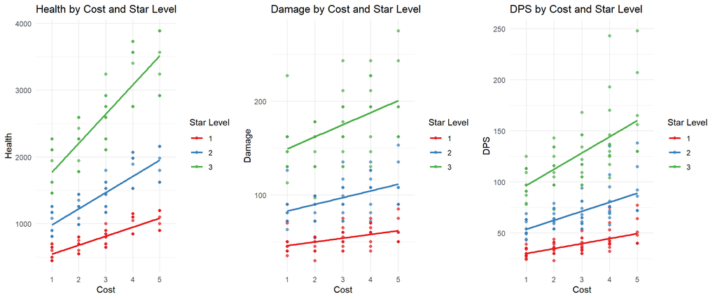

There is a clear trend across all star levels: as the cost increases, all three stats (Health, Damage, and DPS) increase noticeably.

## Set 13: stats by Cost and Star Level

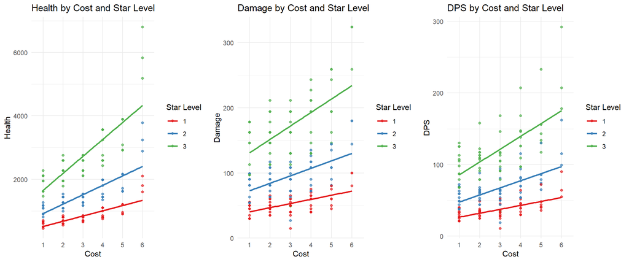

## Set 12 vs Set 13: Average stats Comparison by Cost and Star Level

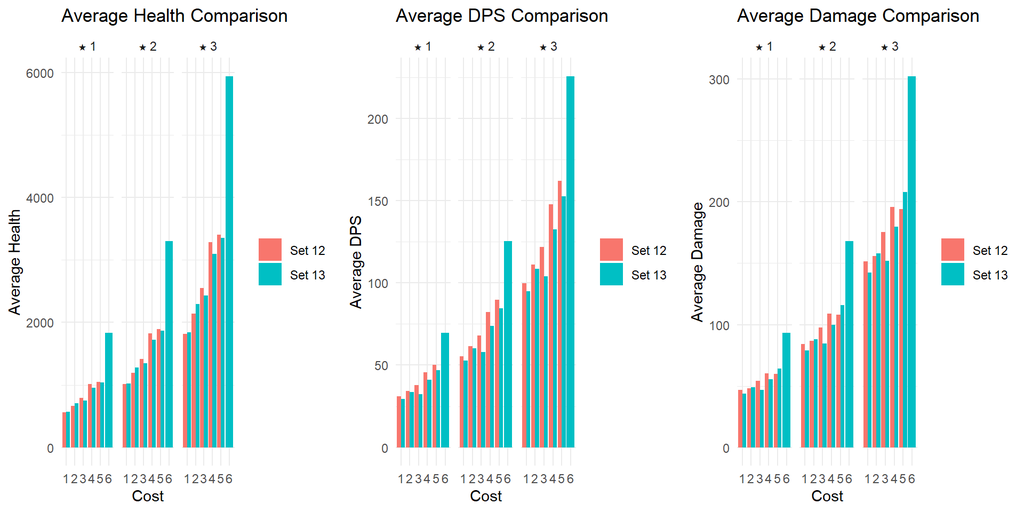

Bar charts indicate that higher costs correspond to higher stats across all star levels. However, the stats of 6-cost champions are significantly higher than those of any other cost category. Additionally, the stats for 1- to 5-cost champions in Set 12 tend to be slightly higher than those in Set 13, which makes the high stats of 6-cost champions even more pronounced.

## Set 12 vs Set 13: Normalized stats Comparison by Cost and Star Level

For these charts, stats are normalized by cost, where 1-star units are worth their base cost (1–6), 2-star units are worth three times their base cost, and 3-star units are worth nine times their base cost (Normalized Stat = Stat / Total Cost at Star Level).

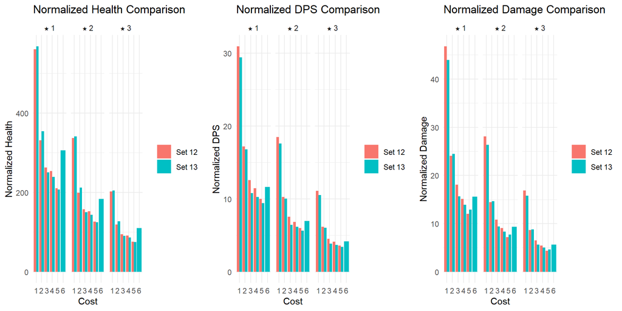

The normalized bar charts show that although 6-cost champions have very high absolute stats, 1-cost champions offer a higher stats-to-cost ratio. When cost is taken into account, the normalized stats trend downward as cost increases, but the exceptionally high stats of 6-cost champions remain evident.

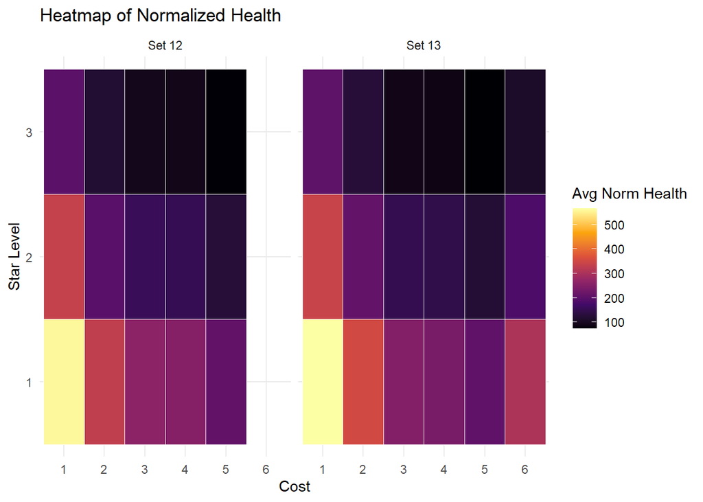

The heatmap agrees with the bar charts above, supporting the claim that 1 costs have significantly higher normalized stats, namely health as shown by the heatmap, as compared to any other cost.

## Set 12 Vs Set 13: Distribution Comparison

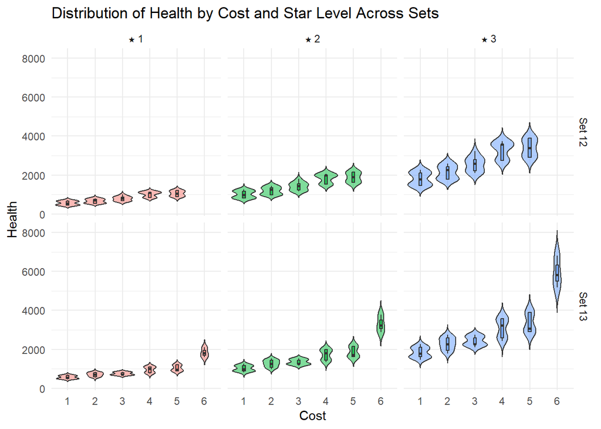

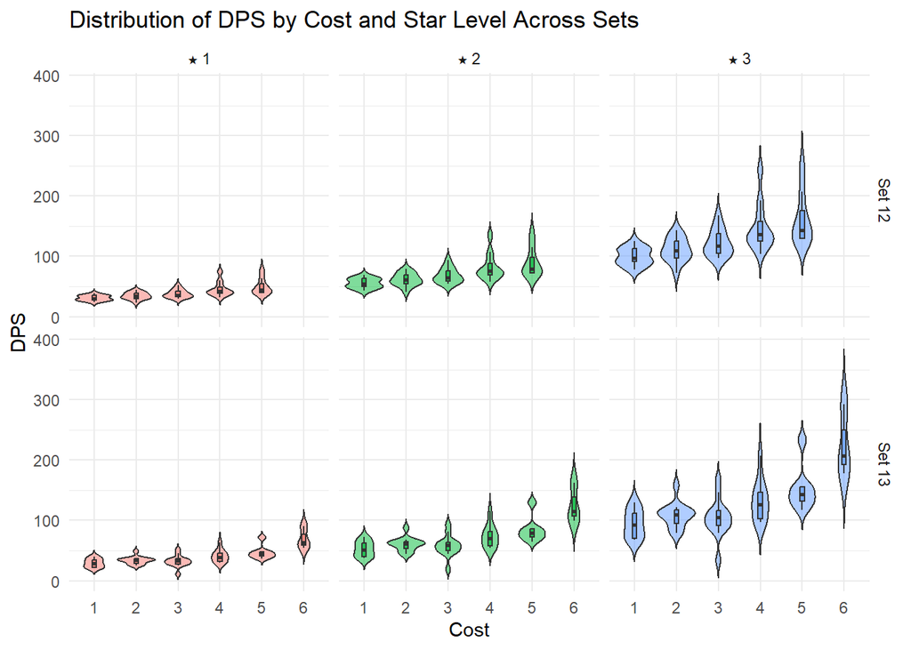

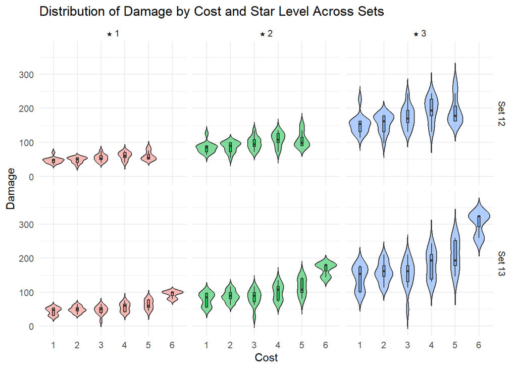

Violin plots reinforce previous trends, showing that higher-cost units with higher star levels generally have higher stats, though there are exceptions. Notably, the DPS of 3-star, 6-cost champions has a wide range, indicating that while some 6-cost champions exhibit very high DPS, others have much lower DPS. This variability highlights the unique impact of 6-cost champions in the game.

# Champion and Trait Win Rate Analysis

So far, we’ve explored how champion stats like health, damage, and DPS scale across costs and star levels in Sets 12 and 13. However, high stats don’t necessarily translate to better performance. To assess how effective champions and traits actually are in-game, we now incorporate **win rate** as our performance metric.

Win rate in this analysis refers to the **Top 1 Rate**, derived from thousands of real team compositions. Each champion’s win rate is averaged across all compositions in which it appears. This allows us to examine whether certain champions or traits consistently contribute to victory — regardless of raw stats.

The following interactive visualizations explore: - How champion cost relates to average win rate  
- Which traits are most strongly associated with winning teams

## Champion Win Rate vs Cost

[interactive chart not shown]

## Trait-Level Win Rate Summary

| Trait | Avg Win Rate | Avg Top 4 Rate | Count | Set |
| --- | --- | --- | --- | --- |
| Blaster | 0.093 | 0.5262 | 5 | Set 12 |
| Dragon | 0.0805 | 0.5495 | 2 | Set 12 |
| Druid | 0.075 | 0.734 | 1 | Set 12 |
| Honeymancy | 0.0745 | 0.5155 | 2 | Set 12 |
| Portal | 0.0745 | 0.336 | 4 | Set 12 |
| Frost | 0.0743 | 0.5953 | 3 | Set 12 |
| Vanguard | 0.0738 | 0.4367 | 10 | Set 12 |
| Arcana | 0.0567 | 0.391 | 3 | Set 12 |
| Hunter | 0.0558 | 0.509 | 4 | Set 12 |
| Shapeshifter | 0.0427 | 0.4044 | 8 | Set 12 |

[output cut: 25 more lines]

# Predicting Win Rate: Stats, Traits, and Models

Model Comparison: R², RMSE, AIC (if applicable)

| Model_Type | Set | Input | R2 | RMSE | AIC |
| --- | --- | --- | --- | --- | --- |
| LM | Set 12 | Stats only | 0.0415 | 0.0578 | -589.4084 |
| LM | Set 12 | Traits only | 1.0000 | 0.0000 | -14690.2538 |
| LM | Set 12 | Both | 1.0000 | 0.0000 | -14690.2538 |
| LM | Set 13 | Stats only | -0.0094 | 0.0165 | -934.0546 |
| LM | Set 13 | Traits only | 1.0000 | 0.0000 | -12722.2031 |
| LM | Set 13 | Both | 1.0000 | 0.0000 | -12722.2031 |
| GAM | Set 12 | Stats only | 0.0415 | 0.0578 | -589.4084 |
| GAM | Set 12 | Traits only | 0.1064 | 0.0527 | -583.9708 |
| GAM | Set 12 | Both | 0.0912 | 0.0526 | -577.0607 |
| GAM | Set 13 | Stats only | 0.0025 | 0.0163 | -935.1633 |
| GAM | Set 13 | Traits only | 0.0415 | 0.0151 | -925.0469 |
| GAM | Set 13 | Both | 0.0158 | 0.0151 | -917.1122 |
| RF | Set 12 | Stats only | -0.1781 | 0.0650 | NA |
| RF | Set 12 | Traits only | 0.3866 | 0.0468 | NA |
| RF | Set 12 | Both | 0.2871 | 0.0517 | NA |
| RF | Set 13 | Stats only | -0.1459 | 0.0177 | NA |
| RF | Set 13 | Traits only | 0.4092 | 0.0130 | NA |
| RF | Set 13 | Both | 0.3555 | 0.0133 | NA |

Random Forest with traits only is the best model overall because it has the highest R^2 and lowest RMSE across both sets, indicating strong predictive performance. Linear models likely overfit, as shown by perfect R^2 and zero RMSE, while GAMs perform worse in both R² and RMSE without gains in AIC. Traits only outperforms stats only and both combined, likely because stats add noise or redundant information.

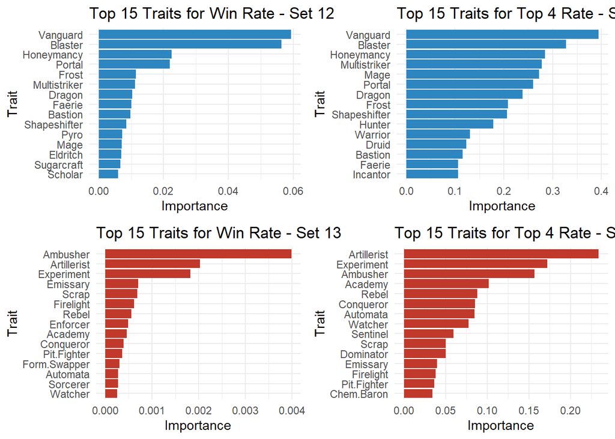

```r
#############################################
# Random Forest (RF) - Trait Importance for Win Rate and Top 4 Rate
#############################################

# Helper function: Fit Random Forest and extract top 15 variable importances
get_top_traits_clean <- function(df, response_var, remove_var) {
  clean_df <- df %>%
    select(-traits, -champions, -all_of(remove_var)) %>%
    drop_na()

  rf_model <- randomForest(
    as.formula(paste(response_var, "~ .")),
    data = clean_df,
    ntree = 500
  )

  imp_vals <- importance(rf_model)
  imp_df <- data.frame(Trait = rownames(imp_vals), Importance = imp_vals[, 1])
  top15 <- imp_df %>%
    arrange(desc(Importance)) %>%
    head(15)
  return(top15)
}

# Extract top traits (removing the other target variable!)
top15_set12_winrate <- get_top_traits_clean(regression_traits_only_set12, "win_rate", "top4_rate")
top15_set12_top4rate <- get_top_traits_clean(regression_traits_only_set12, "top4_rate", "win_rate")
top15_set13_winrate <- get_top_traits_clean(regression_traits_only_set13, "win_rate", "top4_rate")
top15_set13_top4rate <- get_top_traits_clean(regression_traits_only_set13, "top4_rate", "win_rate")

# Helper function to generate a plot
make_plot <- function(df, set_label, metric_label, fill_color) {
  ggplot(df, aes(x = reorder(Trait, Importance), y = Importance)) +
    geom_col(fill = fill_color) +
    coord_flip() +
    labs(
      title = paste("Top 15 Traits for", metric_label, "-", set_label),
      x = "Trait",
      y = "Importance"
    ) +
    theme_minimal()
}

# Create each plot
plot1 <- make_plot(top15_set12_winrate, "Set 12", "Win Rate", "#2E86C1")
plot2 <- make_plot(top15_set12_top4rate, "Set 12", "Top 4 Rate", "#2E86C1")
plot3 <- make_plot(top15_set13_winrate, "Set 13", "Win Rate", "#C0392B")
plot4 <- make_plot(top15_set13_top4rate, "Set 13", "Top 4 Rate", "#C0392B")

# Display plots in 2x2 layout
grid.arrange(plot1, plot2, plot3, plot4, ncol = 2)
```

From the figure above, the best traits for Set 12 are Vanguard, Blaster and Honeymancy, while the best traits for Set 13 are Artillerist, Ambusher and Experiment.

# Summary

This project examined how champion stats, traits, and design shifts between Set 12 and Set 13 in *Teamfight Tactics* (TFT) impact team performance, using thousands of real team compositions and multiple modeling approaches.

### Overall Conclusion

The introduction of 6-cost units in Set 13 redefined the TFT metagame by raising power ceilings while preserving relative scaling rules. However, **raw stats alone do not determine success**. Instead, **team synergy via traits** remains the most reliable pathway to victory. Effective composition building relies not just on strong units, but on how well those units activate and complement each other’s traits.